# Draft Graphics

Chaeyoung, Hong Gi, Gloria, John, James

October 28, 2022

## Data

```r
churchData <- read_csv('data/data.csv')
workingChurchData <-read_survey('data/data.csv', legacy = TRUE)
workingChurchData <- rename(workingChurchData,
                              "Hand Sanitizer?" = "Q15.10",
                              "Social Distancing?" = "Q15.5",
                              "Additional Cleaning?" = "Q15.11",
                              "Removal Touched Item?" = "Q15.15",
                              "Signage of protocols?"= "Q15.4",
                              "Annnouncemeens?" = "Q15.14",
                              "Traffic Control?" = "Q15.12",
                              "Weeks Closed" = "Q30.X...28",
                              "Services Per Week" = "Q29...8") %>%
  drop_na(`Specific denom`) %>%
  mutate(`Weeks Closed` = parse_number(`Weeks Closed`))
```

## Graph 1: Denomination

```r
table(workingChurchData$`Specific denom`)
```

```
##
##      AG     ANG       B       C     CRC CRC RCA     DOC     ECC    ELCA     EVP
##       2     105      30       1     145       3       3       1     138       1
##     LMS      ND     ORC     PCA   PCUSA     RCA     SDA     UMC     WES       X
##       3      64       1     156       1      85       1       2       1       6
```

```r
table(workingChurchData$`Grouped Denom`)
```

```
##
##     C    EP EP MP    MP   ORC     X
##     1   403     3   335     1     6
```

```r
denomchurch <- filter(workingChurchData, `Specific denom` %in% c("ANG", "B", "CRC", "ELCA", "ND", "PCA", "RCA"))
```

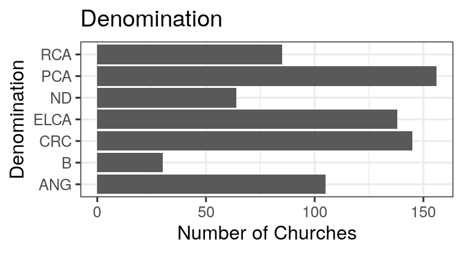

```r
gf_bar(~`Specific denom`, data = denomchurch) %>%
  gf_refine(coord_flip()) %>%
  gf_labs(title = "Denomination",
          x = "Denomination",
          y = "Number of Churches")
```

For this graphic, we would have to think further about the title and color of the graph that we want to highlight the main message of the graph. I think It would be helpful to rename the churches abbriviation too (still not a hundred percent sure).

#### Interpretation

This graphic shows the number of churches in each denomination that filled out the survey. This is relevant because it can help us understand many other graphs based on how many responses we got from certain denomination. The main observation is that the Presbyterian Church in America had the most results followed by the CRC and Evangelical Lutheran Church in America.

## Graph 2: Region

```r
table(workingChurchData$`QR: Region`)
```

```
##
##  MW  NE  SE  SW   W   X
## 276 116 170  51 121  15
```

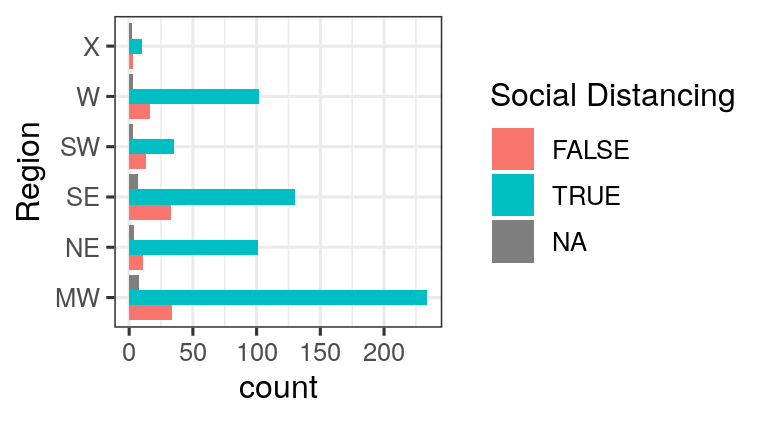

```r
gf_bar(~`QR: Region`, data = workingChurchData,
       fill = ~`Social Distancing?`,
       position = 'dodge') %>%
  gf_refine(coord_flip()) %>%
  gf_labs(x = "Region") %>%
  gf_theme(scale_fill_discrete('Social Distancing'))
```

One thing that we will need to take in consideration is the abbriviation for each region and wether or not we would need to explain each one inddividually. We will need to add the title and subtitle.

#### Interpretation

This graphic shows the region of churches and whether or not they participated in “social distancing” within their church. This is relevant because it helps us understand regionally how people felt about the effectiveness and use of social distancing. We decided to include the use of NA because it shows that certain areas didn’t even entertain the idea of “social distancing”. The main observation is that the the Midwest has the most churches that practiced social distancing, however, we need to take into account what this graph doesn’t show which is that the Midwest has the most responses which makes it look like there are the most there.

## Graph 3: Population or denomination of how long does church closed

```r
denomchurchweek <- denomchurch %>%
  group_by(`Specific denom`) %>%
  summarize(meanweek = mean(`Weeks Closed`, na.rm = TRUE))
```

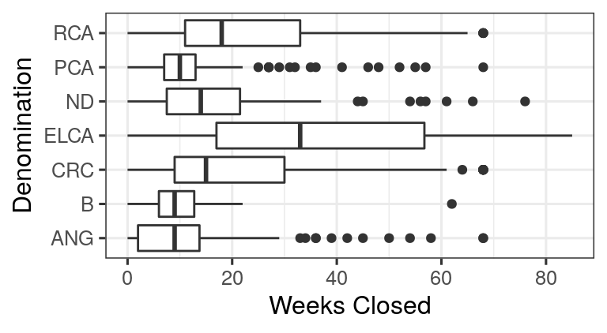

```r
gf_boxplot(`Specific denom` ~ `Weeks Closed`, data = denomchurch) %>%
  gf_labs(x = "Weeks Closed", y = "Denomination")
```

#### Interpretation

In graph three there are individual boxplots for each of the denominations who filled out the survey representing how many weeks their church was closed. Boxplots divide into the quarantines and also show the median and each denomination has a different median showing. Most denominations have some outliers but for the most part are compact showing that the range is close. We can learn the trends of different denominations based on how they compare to others.

## Graph 4

[figure not shown]

```r
gf_bar(~ `Hand Sanitizer?`,
       fill = ~`Additional Cleaning?`,
       data = workingChurchData,
       position = "dodge") %>%
  gf_labs(x = "Hand Sanitizer",
          y = "Number of Churches",
          fill = "Additional Cleaning or Disinfection?")
```

## Graph 5: Congregation required to wear mask all times and How many people in the congregation that have Covid (Q22) and services

trying another one - gloria

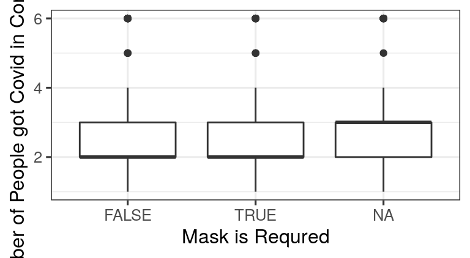

```r
gf_boxplot(Q22 ~ Q30.2, data = workingChurchData) %>%
  gf_labs(y = "Number of People got Covid in Congregation",
          x = "Mask is Requred")
```

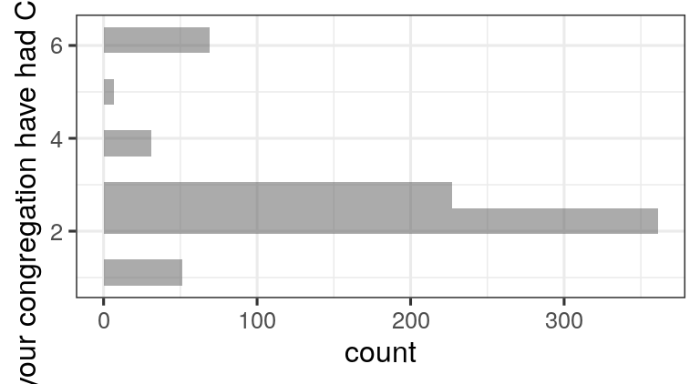

```r
gf_histogram(~Q22, data = workingChurchData, bins = 10)|>
  gf_refine(coord_flip())
```

For the first graph, We will have to think about what to do with the NAs since there is quite a number of it. We will have to finalize all the labels and the bins of the second graph into consideration. Adding titles and thinking of the scales and furture details of it too.

For the Covid variable, since there is no 0 option, we might have to consider whether the NAs mean that there is none or they just didn’t fill the information out.

#### Interpretation

5a. Throughout the churches, church who required a Mask and doesn’t have the same maximal number of people that got COVID in the congregation.

5b. From the graph, most of the churches have at least 2 people who got COVID among the congregation.